# Context & Objectives

**Context**

The Thera bank recently saw a steep decline in the number of users of their credit card, credit cards are a good source of income for banks because of different kinds of fees charged by the banks like annual fees, balance transfer fees, and cash advance fees, late payment fees, foreign transaction fees, and others. Some fees are charged to every user irrespective of usage, while others are charged under specified circumstances.

Customers leaving credit cards services would lead bank to loss, so the bank wants to analyze the data of customers and identify the customers who will leave their credit card services and reason for same – so that bank could improve upon those areas

You as a Data scientist at Thera bank need to come up with a classification model that will help the bank improve its services so that customers do not renounce their credit cards

You need to identify the best possible model that will give the required performance

**Objective**

Explore and visualize the dataset. Build a classification model to predict if the customer is going to churn or not Optimize the model using appropriate techniques Generate a set of insights and recommendations that will help the bank

# Data Dictonary

- CLIENTNUM: Client number. Unique identifier for the customer holding the account
- Attrition_Flag: Internal event (customer activity) variable - if the account is closed then "Attrited Customer" else "Existing Customer"
- Customer_Age: Age in Years
- Gender: Gender of the account holder
- Dependent_count: Number of dependents
- Education_Level: Educational Qualification of the account holder
  - Graduate
  - High School
  - Unknown
  - Uneducated
  - College(refers to a college student)
  - Post-Graduate
  - Doctorate
- Marital_Status: Marital Status of the account holder
- Income_Category: Annual Income Category of the account holder
- Card_Category: Type of Card
- Months_on_book: Period of relationship with the bank
- Total_Relationship_Count: Total no. of products held by the customer
- Months_Inactive_12_mon: No. of months inactive in the last 12 months
- Contacts_Count_12_mon: No. of Contacts between the customer and bank in the last 12 months
- Credit_Limit: Credit Limit on the Credit Card
- Total_Revolving_Bal: Total Revolving Balance on the Credit Card
- Avg_Open_To_Buy: Open to Buy Credit Line (Average of last 12 months)
- Total_Amt_Chng_Q4_Q1: Change in Transaction Amount (Q4 over Q1)
- Total_Trans_Amt: Total Transaction Amount (Last 12 months)
- Total_Trans_Ct: Total Transaction Count (Last 12 months)
- Total_Ct_Chng_Q4_Q1: Change in Transaction Count (Q4 over Q1)
- Avg_Utilization_Ratio: Average Card Utilization Ratio

# Importing Libraries

```python
!pip install scikit-learn==1.2.2 seaborn==0.13.1 matplotlib==3.7.1 numpy==1.25.2 pandas==1.5.3 imbalanced-learn==0.10.1 xgboost==2.0.3 -q --user
```

```python
# importing libraries to support data reading and manipulation
import pandas as pd
import numpy as np

# importing libraries for data visualization
import matplotlib.pyplot as plt
import seaborn as sns

# To load PowerTransformer for outlier transformation
from sklearn.preprocessing import PowerTransformer

# To tune model, get different metric scores, and split data
from sklearn import metrics
from sklearn.metrics import (
    f1_score,
    accuracy_score,
    recall_score,
    precision_score,
    confusion_matrix,
    roc_auc_score,
    ConfusionMatrixDisplay,
    classification_report,
)
from sklearn.model_selection import train_test_split, StratifiedKFold, cross_val_score

# To be used for data scaling and one hot encoding
from sklearn.preprocessing import StandardScaler, MinMaxScaler, OneHotEncoder, LabelEncoder

# To impute missing values
from sklearn.impute import SimpleImputer
from sklearn import metrics

# To oversample and undersample data
from imblearn.over_sampling import SMOTE
from imblearn.under_sampling import RandomUnderSampler

# To do hyperparameter tuning
from sklearn.model_selection import RandomizedSearchCV

# To define maximum number of columns to be displayed in a dataframe
pd.set_option("display.max_columns", None)

# To supress scientific notations for a dataframe
pd.set_option("display.float_format", lambda x: "%.3f" % x)

# To help with model building
from sklearn.tree import DecisionTreeClassifier
from sklearn.ensemble import (
    AdaBoostClassifier,
    GradientBoostingClassifier,
    RandomForestClassifier,
    BaggingClassifier,
)
from xgboost import XGBClassifier

# To supress warnings
import warnings
warnings.filterwarnings("ignore")

from scipy.stats import shapiro
```

# Loading the Dataset

```python
# mounting the drive
from google.colab import drive
drive.mount('/content/drive')
```

```python
# reading the data
df = pd.read_csv("/content/drive/MyDrive/pgp_aiml/advanced_ml/bank_churners.csv")
```

```python
# copying data to another variable to avoid any changes to original data
data = df.copy()
```

# Overview of the Dataset

#### First & Last 5 Rows

```python
# viewing first 5 rows of the dataset
data.head()
```

|  | CLIENTNUM | Attrition_Flag | Customer_Age | Gender | Dependent_count | Education_Level | Marital_Status | Income_Category | Card_Category | Months_on_book | Total_Relationship_Count | Months_Inactive_12_mon | Contacts_Count_12_mon | Credit_Limit | Total_Revolving_Bal | Avg_Open_To_Buy | Total_Amt_Chng_Q4_Q1 | Total_Trans_Amt | Total_Trans_Ct | Total_Ct_Chng_Q4_Q1 | Avg_Utilization_Ratio |
| --- | --- | --- | --- | --- | --- | --- | --- | --- | --- | --- | --- | --- | --- | --- | --- | --- | --- | --- | --- | --- | --- |
| 0 | 768805383 | Existing Customer | 45 | M | 3 | High School | Married | $60K - $80K | Blue | 39 | 5 | 1 | 3 | 12691.000 | 777 | 11914.000 | 1.335 | 1144 | 42 | 1.625 | 0.061 |
| 1 | 818770008 | Existing Customer | 49 | F | 5 | Graduate | Single | Less than $40K | Blue | 44 | 6 | 1 | 2 | 8256.000 | 864 | 7392.000 | 1.541 | 1291 | 33 | 3.714 | 0.105 |
| 2 | 713982108 | Existing Customer | 51 | M | 3 | Graduate | Married | $80K - $120K | Blue | 36 | 4 | 1 | 0 | 3418.000 | 0 | 3418.000 | 2.594 | 1887 | 20 | 2.333 | 0.000 |
| 3 | 769911858 | Existing Customer | 40 | F | 4 | High School | NaN | Less than $40K | Blue | 34 | 3 | 4 | 1 | 3313.000 | 2517 | 796.000 | 1.405 | 1171 | 20 | 2.333 | 0.760 |
| 4 | 709106358 | Existing Customer | 40 | M | 3 | Uneducated | Married | $60K - $80K | Blue | 21 | 5 | 1 | 0 | 4716.000 | 0 | 4716.000 | 2.175 | 816 | 28 | 2.500 | 0.000 |

```python
# viewing last 5 rows of the dataset
data.tail()
```

|  | CLIENTNUM | Attrition_Flag | Customer_Age | Gender | Dependent_count | Education_Level | Marital_Status | Income_Category | Card_Category | Months_on_book | Total_Relationship_Count | Months_Inactive_12_mon | Contacts_Count_12_mon | Credit_Limit | Total_Revolving_Bal | Avg_Open_To_Buy | Total_Amt_Chng_Q4_Q1 | Total_Trans_Amt | Total_Trans_Ct | Total_Ct_Chng_Q4_Q1 | Avg_Utilization_Ratio |
| --- | --- | --- | --- | --- | --- | --- | --- | --- | --- | --- | --- | --- | --- | --- | --- | --- | --- | --- | --- | --- | --- |
| 10122 | 772366833 | Existing Customer | 50 | M | 2 | Graduate | Single | $40K - $60K | Blue | 40 | 3 | 2 | 3 | 4003.000 | 1851 | 2152.000 | 0.703 | 15476 | 117 | 0.857 | 0.462 |
| 10123 | 710638233 | Attrited Customer | 41 | M | 2 | NaN | Divorced | $40K - $60K | Blue | 25 | 4 | 2 | 3 | 4277.000 | 2186 | 2091.000 | 0.804 | 8764 | 69 | 0.683 | 0.511 |
| 10124 | 716506083 | Attrited Customer | 44 | F | 1 | High School | Married | Less than $40K | Blue | 36 | 5 | 3 | 4 | 5409.000 | 0 | 5409.000 | 0.819 | 10291 | 60 | 0.818 | 0.000 |
| 10125 | 717406983 | Attrited Customer | 30 | M | 2 | Graduate | NaN | $40K - $60K | Blue | 36 | 4 | 3 | 3 | 5281.000 | 0 | 5281.000 | 0.535 | 8395 | 62 | 0.722 | 0.000 |
| 10126 | 714337233 | Attrited Customer | 43 | F | 2 | Graduate | Married | Less than $40K | Silver | 25 | 6 | 2 | 4 | 10388.000 | 1961 | 8427.000 | 0.703 | 10294 | 61 | 0.649 | 0.189 |

- The `CLIENTNUM` column contains unique values
- The `attrition_flag` and `gender` present binary values
- We can observe some missing values that will require our attention

#### Shape of the Dataset

```python
# getting the number of rows and columns
num_rows, num_columns = data.shape

# printing the result
print(f'The dataset has {num_rows} rows and {num_columns} columns.')
```

```
The dataset has 10127 rows and 21 columns.
```

#### Colums Data Types

```python
# using the info() function to display information about the DataFrame
data.info()
```

```
<class 'pandas.core.frame.DataFrame'>
RangeIndex: 10127 entries, 0 to 10126
Data columns (total 21 columns):
 #   Column                    Non-Null Count  Dtype
---  ------                    --------------  -----
 0   CLIENTNUM                 10127 non-null  int64
 1   Attrition_Flag            10127 non-null  object
 2   Customer_Age              10127 non-null  int64
 3   Gender                    10127 non-null  object
 4   Dependent_count           10127 non-null  int64
 5   Education_Level           8608 non-null   object
 6   Marital_Status            9378 non-null   object
 7   Income_Category           10127 non-null  object
 8   Card_Category             10127 non-null  object
 9   Months_on_book            10127 non-null  int64
 10  Total_Relationship_Count  10127 non-null  int64
 11  Months_Inactive_12_mon    10127 non-null  int64
 12  Contacts_Count_12_mon     10127 non-null  int64
 13  Credit_Limit              10127 non-null  float64
 14  Total_Revolving_Bal       10127 non-null  int64
 15  Avg_Open_To_Buy           10127 non-null  float64
 16  Total_Amt_Chng_Q4_Q1      10127 non-null  float64
 17  Total_Trans_Amt           10127 non-null  int64
 18  Total_Trans_Ct            10127 non-null  int64
 19  Total_Ct_Chng_Q4_Q1       10127 non-null  float64
 20  Avg_Utilization_Ratio     10127 non-null  float64
dtypes: float64(5), int64(10), object(6)
memory usage: 1.6+ MB
```

- 6 columns are object types while the rest are numerical
- 2 columns have less than 10127 non-null values, meaning that we're encountering missing values in those columns

#### Converting Objects to Categories

```python
cols = data.select_dtypes(['object'])
cols.columns
```

```
Index(['Attrition_Flag', 'Gender', 'Education_Level', 'Marital_Status',
       'Income_Category', 'Card_Category'],
      dtype='object')
```

```python
for i in cols.columns:
    data[i] = data[i].astype('category')
```

```python
data.info()
```

```
<class 'pandas.core.frame.DataFrame'>
RangeIndex: 10127 entries, 0 to 10126
Data columns (total 21 columns):
 #   Column                    Non-Null Count  Dtype
---  ------                    --------------  -----
 0   CLIENTNUM                 10127 non-null  int64
 1   Attrition_Flag            10127 non-null  category
 2   Customer_Age              10127 non-null  int64
 3   Gender                    10127 non-null  category
 4   Dependent_count           10127 non-null  int64
 5   Education_Level           8608 non-null   category
 6   Marital_Status            9378 non-null   category
 7   Income_Category           10127 non-null  category
 8   Card_Category             10127 non-null  category
 9   Months_on_book            10127 non-null  int64
 10  Total_Relationship_Count  10127 non-null  int64
 11  Months_Inactive_12_mon    10127 non-null  int64
 12  Contacts_Count_12_mon     10127 non-null  int64
 13  Credit_Limit              10127 non-null  float64
 14  Total_Revolving_Bal       10127 non-null  int64
 15  Avg_Open_To_Buy           10127 non-null  float64
 16  Total_Amt_Chng_Q4_Q1      10127 non-null  float64
 17  Total_Trans_Amt           10127 non-null  int64
 18  Total_Trans_Ct            10127 non-null  int64
 19  Total_Ct_Chng_Q4_Q1       10127 non-null  float64
 20  Avg_Utilization_Ratio     10127 non-null  float64
dtypes: category(6), float64(5), int64(10)
memory usage: 1.2 MB
```

#### Unique Categories

```python
cols_cat= data.select_dtypes(['category'])
```

```python
for i in cols_cat.columns:
    print('Unique values in',i, 'are :')
    print(cols_cat[i].value_counts())
    print('*'*50)
```

```
Unique values in Attrition_Flag are :
Attrition_Flag
Existing Customer    8500
Attrited Customer    1627
Name: count, dtype: int64
Unique values in Gender are :
Gender
F    5358
M    4769
Name: count, dtype: int64
Unique values in Education_Level are :
Education_Level
Graduate         3128
High School      2013
Uneducated       1487
College          1013
Post-Graduate     516
Doctorate         451
Name: count, dtype: int64
Unique values in Marital_Status are :
Marital_Status
Married     4687
Single      3943
Divorced     748
Name: count, dtype: int64
Unique values in Income_Category are :
Income_Category
Less than $40K    3561
$40K - $60K       1790
$80K - $120K      1535
$60K - $80K       1402
abc               1112
$120K +            727
Name: count, dtype: int64
Unique values in Card_Category are :
Card_Category
Blue        9436
Silver       555
Gold         116
Platinum      20
Name: count, dtype: int64
```

- Were observing some imbalance in our target variable, since there are more customers who did not attrite comparing to those who did. Something we'll need to address in later stages.

#### Unique Values

```python
# Observing unique values in each column of the dataset
data.nunique()
```

```
CLIENTNUM                   10127
Attrition_Flag                  2
Customer_Age                   45
Gender                          2
Dependent_count                 6
Education_Level                 6
Marital_Status                  3
Income_Category                 6
Card_Category                   4
Months_on_book                 44
Total_Relationship_Count        6
Months_Inactive_12_mon          7
Contacts_Count_12_mon           7
Credit_Limit                 6205
Total_Revolving_Bal          1974
Avg_Open_To_Buy              6813
Total_Amt_Chng_Q4_Q1         1158
Total_Trans_Amt              5033
Total_Trans_Ct                126
Total_Ct_Chng_Q4_Q1           830
Avg_Utilization_Ratio         964
dtype: int64
```

#### Duplicate Values

```python
# checking for duplicate values
data.duplicated().sum()
```

```
0
```

There are no duplicate values in this dataset

#### Missing Values

```python
# checking for null values
data.isnull().sum()
```

```
CLIENTNUM                      0
Attrition_Flag                 0
Customer_Age                   0
Gender                         0
Dependent_count                0
Education_Level             1519
Marital_Status               749
Income_Category                0
Card_Category                  0
Months_on_book                 0
Total_Relationship_Count       0
Months_Inactive_12_mon         0
Contacts_Count_12_mon          0
Credit_Limit                   0
Total_Revolving_Bal            0
Avg_Open_To_Buy                0
Total_Amt_Chng_Q4_Q1           0
Total_Trans_Amt                0
Total_Trans_Ct                 0
Total_Ct_Chng_Q4_Q1            0
Avg_Utilization_Ratio          0
dtype: int64
```

- `Education_level` column has 15% missing values out of total observations.
- `Marital_Status` column has 7% missing values out of total observations.
- To note that in addition we will be addressing `Income_Category` 'abc' as null values

We will input these values after we split the data into train, validation and test sets.

#### Statistical Summary

```python
# checking the statistical summary of the data
data.describe(include='all').T
```

|  | count | unique | top | freq | mean | std | min | 25% | 50% | 75% | max |
| --- | --- | --- | --- | --- | --- | --- | --- | --- | --- | --- | --- |
| CLIENTNUM | 10127.000 | NaN | NaN | NaN | 739177606.334 | 36903783.450 | 708082083.000 | 713036770.500 | 717926358.000 | 773143533.000 | 828343083.000 |
| Attrition_Flag | 10127 | 2 | Existing Customer | 8500 | NaN | NaN | NaN | NaN | NaN | NaN | NaN |
| Customer_Age | 10127.000 | NaN | NaN | NaN | 46.326 | 8.017 | 26.000 | 41.000 | 46.000 | 52.000 | 73.000 |
| Gender | 10127 | 2 | F | 5358 | NaN | NaN | NaN | NaN | NaN | NaN | NaN |
| Dependent_count | 10127.000 | NaN | NaN | NaN | 2.346 | 1.299 | 0.000 | 1.000 | 2.000 | 3.000 | 5.000 |
| Education_Level | 8608 | 6 | Graduate | 3128 | NaN | NaN | NaN | NaN | NaN | NaN | NaN |
| Marital_Status | 9378 | 3 | Married | 4687 | NaN | NaN | NaN | NaN | NaN | NaN | NaN |
| Income_Category | 10127 | 6 | Less than $40K | 3561 | NaN | NaN | NaN | NaN | NaN | NaN | NaN |
| Card_Category | 10127 | 4 | Blue | 9436 | NaN | NaN | NaN | NaN | NaN | NaN | NaN |
| Months_on_book | 10127.000 | NaN | NaN | NaN | 35.928 | 7.986 | 13.000 | 31.000 | 36.000 | 40.000 | 56.000 |
| Total_Relationship_Count | 10127.000 | NaN | NaN | NaN | 3.813 | 1.554 | 1.000 | 3.000 | 4.000 | 5.000 | 6.000 |
| Months_Inactive_12_mon | 10127.000 | NaN | NaN | NaN | 2.341 | 1.011 | 0.000 | 2.000 | 2.000 | 3.000 | 6.000 |
| Contacts_Count_12_mon | 10127.000 | NaN | NaN | NaN | 2.455 | 1.106 | 0.000 | 2.000 | 2.000 | 3.000 | 6.000 |
| Credit_Limit | 10127.000 | NaN | NaN | NaN | 8631.954 | 9088.777 | 1438.300 | 2555.000 | 4549.000 | 11067.500 | 34516.000 |
| Total_Revolving_Bal | 10127.000 | NaN | NaN | NaN | 1162.814 | 814.987 | 0.000 | 359.000 | 1276.000 | 1784.000 | 2517.000 |
| Avg_Open_To_Buy | 10127.000 | NaN | NaN | NaN | 7469.140 | 9090.685 | 3.000 | 1324.500 | 3474.000 | 9859.000 | 34516.000 |
| Total_Amt_Chng_Q4_Q1 | 10127.000 | NaN | NaN | NaN | 0.760 | 0.219 | 0.000 | 0.631 | 0.736 | 0.859 | 3.397 |
| Total_Trans_Amt | 10127.000 | NaN | NaN | NaN | 4404.086 | 3397.129 | 510.000 | 2155.500 | 3899.000 | 4741.000 | 18484.000 |
| Total_Trans_Ct | 10127.000 | NaN | NaN | NaN | 64.859 | 23.473 | 10.000 | 45.000 | 67.000 | 81.000 | 139.000 |
| Total_Ct_Chng_Q4_Q1 | 10127.000 | NaN | NaN | NaN | 0.712 | 0.238 | 0.000 | 0.582 | 0.702 | 0.818 | 3.714 |
| Avg_Utilization_Ratio | 10127.000 | NaN | NaN | NaN | 0.275 | 0.276 | 0.000 | 0.023 | 0.176 | 0.503 | 0.999 |

```python
data.describe(include=['category']).T
```

|  | count | unique | top | freq |
| --- | --- | --- | --- | --- |
| Attrition_Flag | 10127 | 2 | Existing Customer | 8500 |
| Gender | 10127 | 2 | F | 5358 |
| Education_Level | 8608 | 6 | Graduate | 3128 |
| Marital_Status | 9378 | 3 | Married | 4687 |
| Income_Category | 10127 | 6 | Less than $40K | 3561 |
| Card_Category | 10127 | 4 | Blue | 9436 |

Numerical

Categorical

- `Attrition_Flag` is a binary column merely indicative of two unique categories "Existing Customer" and "Attrited Customer" where "Existing Customer" appears to be the most prevalent value in the dataset
- `Gender` is a binary column also indicative of two unique categories "F" and "M" where "F" appears to be the most prevalent value in the dataset
- `Education_Level` is merely indicative of 6 unique categories where "Graduate" appears to be the most prevalent value in the dataset
- `Marital_Status` is also indicative of 3 unique categories where "Married" appears to be the most prevalent value in the dataset
- `Income_Category` similary is also an indication of 6 unique categories where "leass than 40k" appears to be the most prevalent value in the dataset
- `Card_Category` is also indicative of 4 unqiue categories where "blue" appears to be the most prevalent value in the dataset

#### Encoding Attrition Flag

```python
## Encoding Existing and Attrited customers to 0 and 1 respectively, for analysis.
data["Attrition_Flag"].replace("Existing Customer", 0, inplace=True)
data["Attrition_Flag"].replace("Attrited Customer", 1, inplace=True)
```

# Exploratory Data Analysis

## EDA Functions

```python
# function to plot a boxplot and a histogram along the same scale.


def histogram_boxplot(data, feature, figsize=(12, 7), kde=False, bins=None):
    """
    Boxplot and histogram combined

    data: dataframe
    feature: dataframe column
    figsize: size of figure (default (12,7))
    kde: whether to the show density curve (default False)
    bins: number of bins for histogram (default None)
    """
    f2, (ax_box2, ax_hist2) = plt.subplots(
        nrows=2,  # Number of rows of the subplot grid= 2
        sharex=True,  # x-axis will be shared among all subplots
        gridspec_kw={"height_ratios": (0.25, 0.75)},
        figsize=figsize,
    )  # creating the 2 subplots
    sns.boxplot(
        data=data, x=feature, ax=ax_box2, showmeans=True, color="violet"
    )  # boxplot will be created and a triangle will indicate the mean value of the column
    sns.histplot(
        data=data, x=feature, kde=kde, ax=ax_hist2, bins=bins, palette="winter"
    ) if bins else sns.histplot(
        data=data, x=feature, kde=kde, ax=ax_hist2
    )  # For histogram
    ax_hist2.axvline(
        data[feature].mean(), color="green", linestyle="--"
    )  # Add mean to the histogram
    ax_hist2.axvline(
        data[feature].median(), color="black", linestyle="-"
    )  # Add median to the histogram
```

```python
# function to create labeled barplots


def labeled_barplot(data, feature, perc=False, n=None):
    """
    Barplot with percentage at the top

    data: dataframe
    feature: dataframe column
    perc: whether to display percentages instead of count (default is False)
    n: displays the top n category levels (default is None, i.e., display all levels)
    """

    total = len(data[feature])  # length of the column
    count = data[feature].nunique()
    if n is None:
        plt.figure(figsize=(count + 1, 5))
    else:
        plt.figure(figsize=(n + 1, 5))

    plt.xticks(rotation=90, fontsize=10)
    ax = sns.countplot(
        data=data,
        x=feature,
        palette="Paired",
        order=data[feature].value_counts().index[:n].sort_values(),
    )

    for p in ax.patches:
        if perc == True:
            label = "{:.1f}%".format(
                100 * p.get_height() / total
            )  # percentage of each class of the category
        else:
            label = int(p.get_height())  # count of each level of the category

        x = p.get_x() + p.get_width() / 2  # width of the plot
        y = p.get_height()  # height of the plot

        ax.annotate(
            label,
            (x, y),
            ha="center",
            va="center",
            size=12,
            xytext=(0, 5),
            textcoords="offset points",
        )  # annotate the percentage

    plt.show()  # show the plot
```

```python
# function to plot stacked bar chart

def stacked_barplot(data, predictor, target):
    """
    Print the category counts and plot a stacked bar chart

    data: dataframe
    predictor: independent variable
    target: target variable
    """
    count = data[predictor].nunique()
    sorter = data[target].value_counts().index[-1]
    tab1 = pd.crosstab(data[predictor], data[target], margins=True).sort_values(
        by=sorter, ascending=False
    )
    print(tab1)
    print("-" * 120)
    tab = pd.crosstab(data[predictor], data[target], normalize="index").sort_values(
        by=sorter, ascending=False
    )
    tab.plot(kind="bar", stacked=True, figsize=(count + 1, 5))
    plt.legend(
        loc="lower left", frameon=False,
    )
    plt.legend(loc="upper left", bbox_to_anchor=(1, 1))
    plt.show()
```

```python
### Function to plot distributions

def distribution_plot_wrt_target(data, predictor, target):

    fig, axs = plt.subplots(2, 2, figsize=(12, 10))

    target_uniq = data[target].unique()

    axs[0, 0].set_title("Distribution of target for target=" + str(target_uniq[0]))
    sns.histplot(
        data=data[data[target] == target_uniq[0]],
        x=predictor,
        kde=True,
        ax=axs[0, 0],
        color="teal",
    )

    axs[0, 1].set_title("Distribution of target for target=" + str(target_uniq[1]))
    sns.histplot(
        data=data[data[target] == target_uniq[1]],
        x=predictor,
        kde=True,
        ax=axs[0, 1],
        color="orange",
    )

    axs[1, 0].set_title("Boxplot w.r.t target")
    sns.boxplot(data=data, x=target, y=predictor, ax=axs[1, 0], palette="gist_rainbow")

    axs[1, 1].set_title("Boxplot (without outliers) w.r.t target")
    sns.boxplot(
        data=data,
        x=target,
        y=predictor,
        ax=axs[1, 1],
        showfliers=False,
        palette="gist_rainbow",
    )

    plt.tight_layout()
    plt.show()
```

## Univariate Analysis

### Numerical Columns Overview

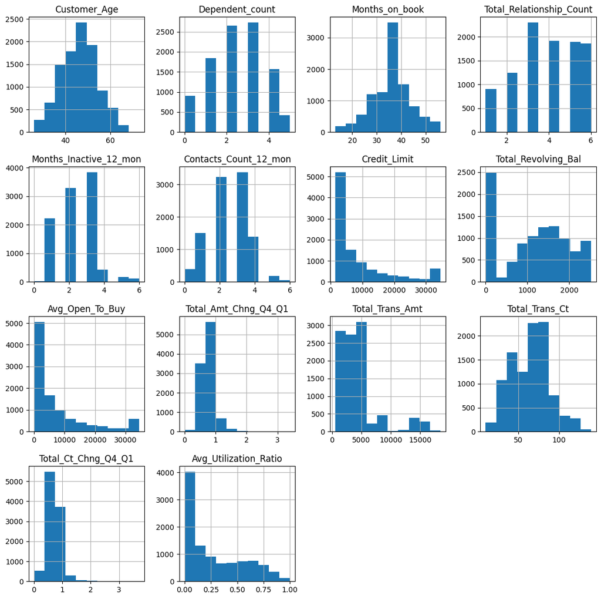

```python
#Making a list for numerical columns
num_col = [
    "Customer_Age",
    "Dependent_count",
    "Months_on_book",
    "Total_Relationship_Count",
    "Months_Inactive_12_mon",
    "Contacts_Count_12_mon",
    "Credit_Limit",
    "Total_Revolving_Bal",
    "Avg_Open_To_Buy",
    "Total_Amt_Chng_Q4_Q1",
    "Total_Trans_Amt",
    "Total_Trans_Ct",
    "Total_Ct_Chng_Q4_Q1",
    "Avg_Utilization_Ratio"
]

# creating histograms for numerical variables
data[num_col].hist(figsize=(14, 14))
plt.show()
```

#### Age

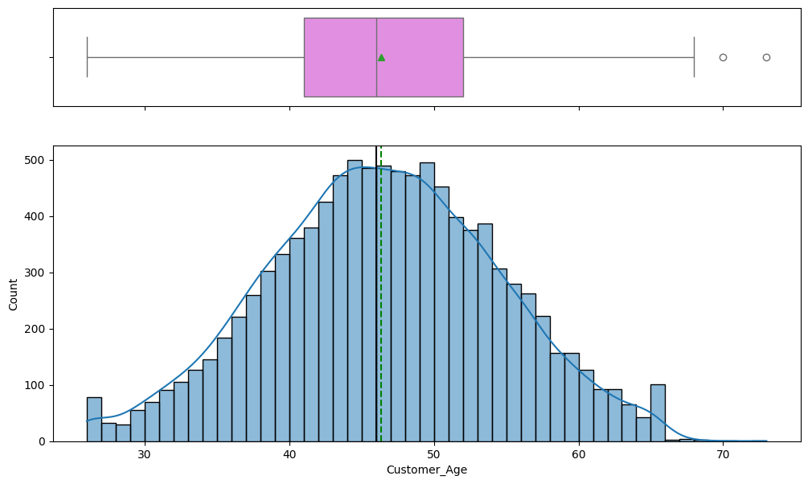

```python
# Generating a histogram and boxplot to observe distribution
histogram_boxplot(data, "Customer_Age", kde=True)
```

#### Dependent

```
Dependent_count
0     904
1    1838
2    2655
3    2732
4    1574
5     424
Name: CLIENTNUM, dtype: int64
```

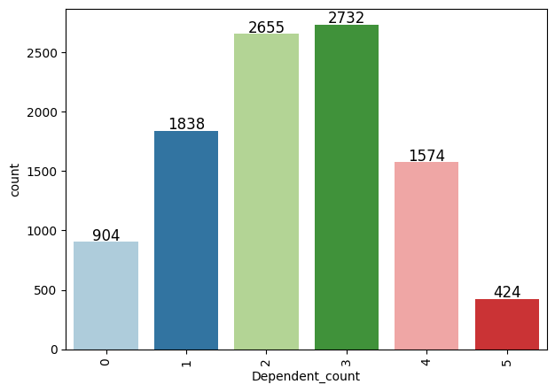

```python
# customer count per dependent count
dependent_count = data.groupby('Dependent_count')['CLIENTNUM'].count()
print(dependent_count)
print()

# Generating a barplot to observe distribution
labeled_barplot(data, "Dependent_count")
```

#### Months on Book

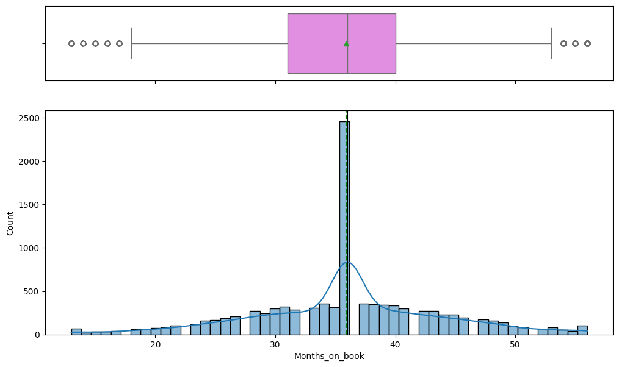

```python
# Generating a histogram and boxplot to observe distribution
histogram_boxplot(data, "Months_on_book", kde=True)
```

- Despite the appearance of normality, the peak observed in the middle of the distribution suggests a strong central tendency where a significant portion of observations cluster around a central value - in this case the mean appears to fall on 35 months with about 2500 counts or about 5 times more than other months on book.
- There's indication of outliers in both lower and upper quartiles.

```python
# Extract the column of interest
column_data = data["Months_on_book"]

# Perform Shapiro-Wilk test for normality
statistic, p_value = shapiro(column_data)

# Interpret the results
alpha = 0.05  # Significance level
print("Shapiro-Wilk Test for Normality:")
print("Statistic:", statistic)
print("p-value:", p_value)
if p_value > alpha:
    print("The data looks normally distributed (fail to reject H0)")
else:
    print("The data does not look normally distributed (reject H0)")
```

```
Shapiro-Wilk Test for Normality:
Statistic: 0.9769161343574524
p-value: 1.9024193865411893e-37
The data does not look normally distributed (reject H0)
```

- Supporting the above statement, a Shapiro-Wilk test conducted as extra validation seems to indicate that the data may be significantly deviating from a normal distribution, indicating that the assumption of normality is not met for this column.

#### Total Relationship Count

```
Total_Relationship_Count
1     910
2    1243
3    2305
4    1912
5    1891
6    1866
Name: CLIENTNUM, dtype: int64
```

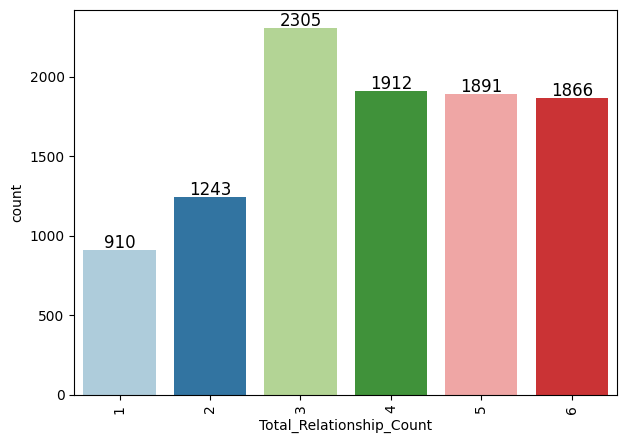

```python
# customer count per number of products held by the customer
relationship_count = data.groupby('Total_Relationship_Count')['CLIENTNUM'].count()
print(relationship_count)
print()

# Generating a barplot to observe distribution
labeled_barplot(data, "Total_Relationship_Count")
```

- We're observing a tendency where the minority of customers seem to only have 1 (9%) or 2 (12%) products, with 3 products having the most customer count (23%) followed by 4 or more.

#### Months Inactive

```
Months_Inactive_12_mon
0      29
1    2233
2    3282
3    3846
4     435
5     178
6     124
Name: CLIENTNUM, dtype: int64
```

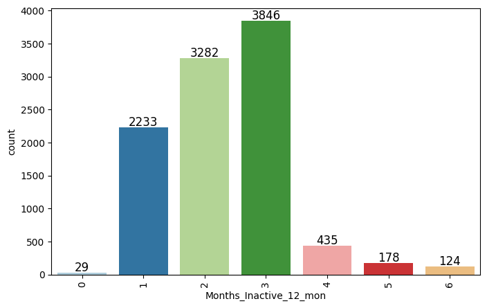

```python
# customer count per months of inactivity
inactivity_count = data.groupby('Months_Inactive_12_mon')['CLIENTNUM'].count()
print(inactivity_count)
print()

# Generating a barplot to observe distribution
labeled_barplot(data, "Months_Inactive_12_mon")
```

- The distribution seems to display some skeweness towards the right.
- The majority of the bank customers seem to have had at least 1 (22%), 2 (32%) or 3 (38%) months of inactivity with the bank.
- A vast minority of the bank customers had no inactivity with the bank (0.28%)
- A vast minority of the bank customers had 4 (4%), 5 (1.75%) and 6 (1.22%) months of inactivity.

#### Contacts Count 12 Months

```
Contacts_Count_12_mon
0     399
1    1499
2    3227
3    3380
4    1392
5     176
6      54
Name: CLIENTNUM, dtype: int64
```

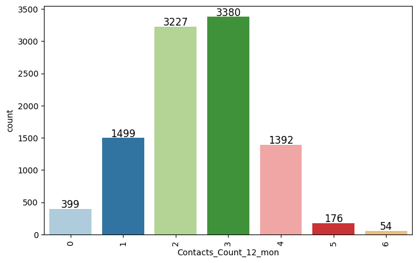

```python
# customer count per contact
contact_count = data.groupby('Contacts_Count_12_mon')['CLIENTNUM'].count()
print(contact_count)
print()

# Generating a barplot to observe distribution
labeled_barplot(data, "Contacts_Count_12_mon")
```

- The vast majority of the customers seem to have contacted the bank at least 2 (32%) or 3 (33%) times followed by 1 (15%) and 4 (14%) times.
- A vast minority of customers have either never contacted the bank (4%) or have contacted 5 (2%) or 6 (0.5%) times.
- It will be interesting to explore it's correlation with attrition, as contacting the bank can often be related to a number of scenarios.

#### Credit Limit

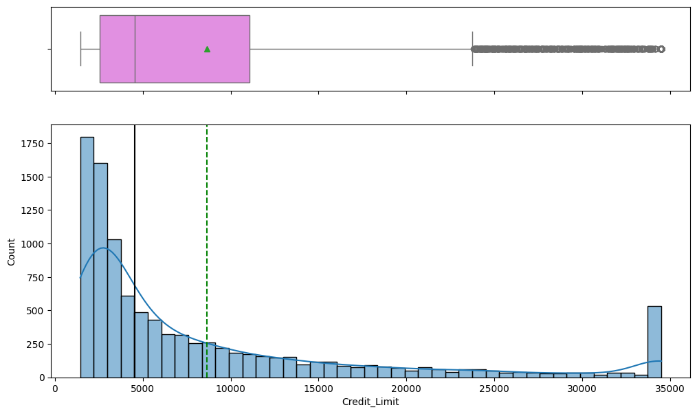

```python
# Generating a histogram and boxplot to observe distribution
histogram_boxplot(data, "Credit_Limit", kde=True)
```

- The distribution displays significant skeweness towards the right, with many outliers observed in the upper quartile.
- The majority of clients appear to be on a lower credit limit below 11k USD.

#### Total Revolving Balance

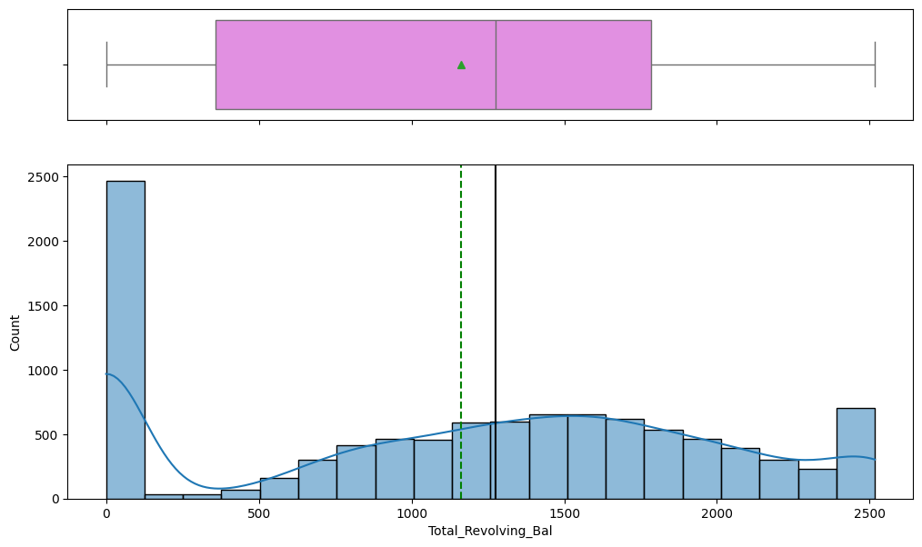

```python
# Generating a histogram and boxplot to observe distribution
histogram_boxplot(data, "Total_Revolving_Bal", kde=True)
```

#### Average Open to Buy

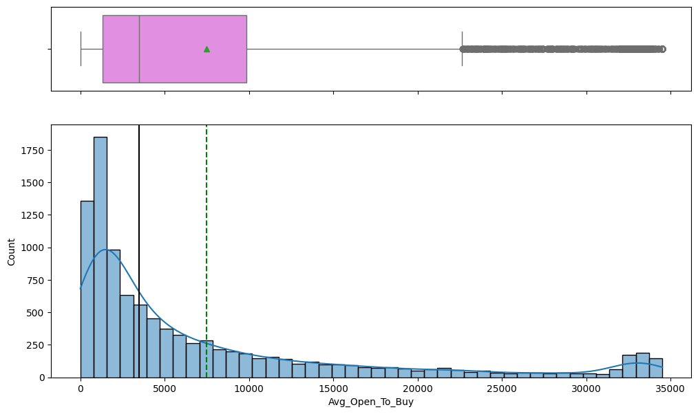

```python
# Generating a histogram and boxplot to observe distribution
histogram_boxplot(data, "Avg_Open_To_Buy", kde=True)
```

- The distribution displays significant skeweness towards the right, with many outliers observed in the upper quartile.
- A significant number of observations seem to fall under 10k. It will be interesting to observe its correlation with 'Credit Limit' to fully understand it's significance

#### Ratio of Total Transaction Amount in Q4 over Q1

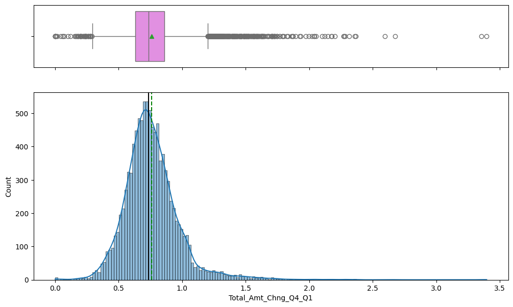

```python
# Generating a histogram and boxplot to observe distribution
histogram_boxplot(data, "Total_Amt_Chng_Q4_Q1", kde=True)
```

- The distribution displays significant skeweness towards the right, with many outliers observed in the upper and lower quartiles.
- With a mean set at a ratio of 0.760, it indicates that a vast majority of customers may have seen a decrease or no change in transaction amount in Q4 over Q1

#### Ratio of Total Transaction Count in Q4 over Q1

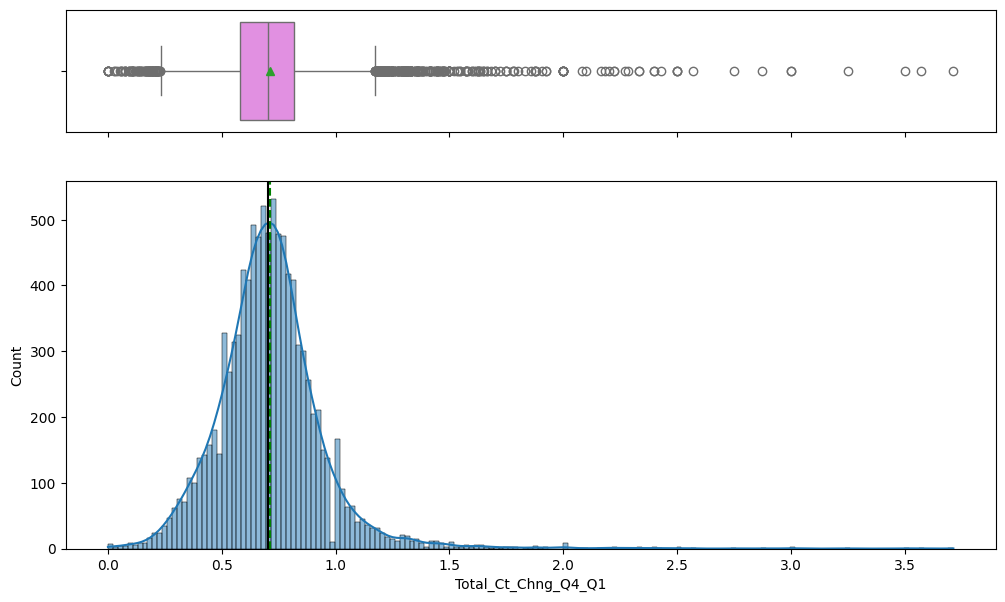

```python
# Generating a histogram and boxplot to observe distribution
histogram_boxplot(data, "Total_Ct_Chng_Q4_Q1", kde=True)
```

- The distribution displays significant skeweness towards the right, with many outliers observed in the upper and lower quartiles.
- With a mean set at a ratio of 0.712, it indicates that the average customer seems to have had 30% less total transaction counts than Q1, indicating a slight preference to conduct transactions in Q1 vs Q4.

#### Total Transaction Amount

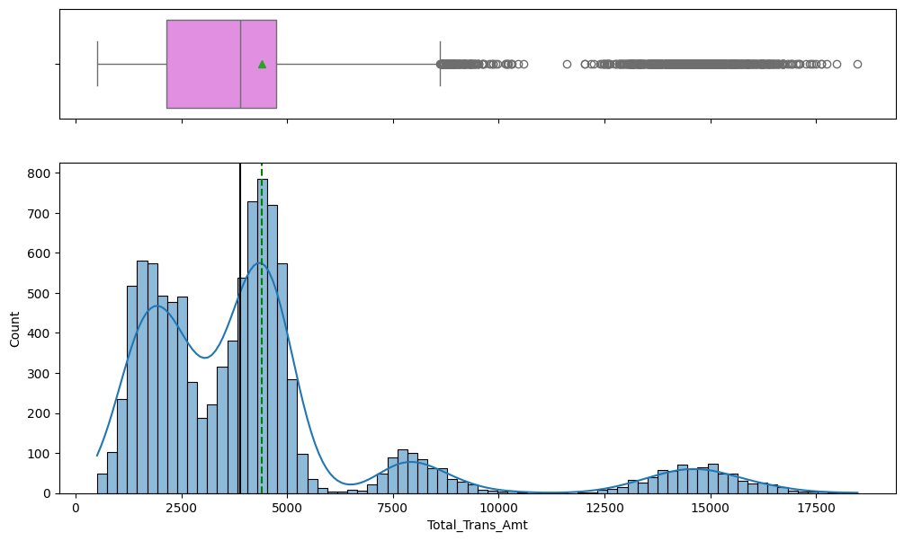

```python
# Generating a histogram and boxplot to observe distribution
histogram_boxplot(data, "Total_Trans_Amt", kde=True)
```

- The distribution displays significant skeweness towards the right, with many outliers observed in the upper quartile.
- Some customers seem to be performing much higher transactions than the median with the majority of transactions appearing to be falling under 6000 USD while the highest transaction reaching as much as 17500k.

#### Total Transaction Count

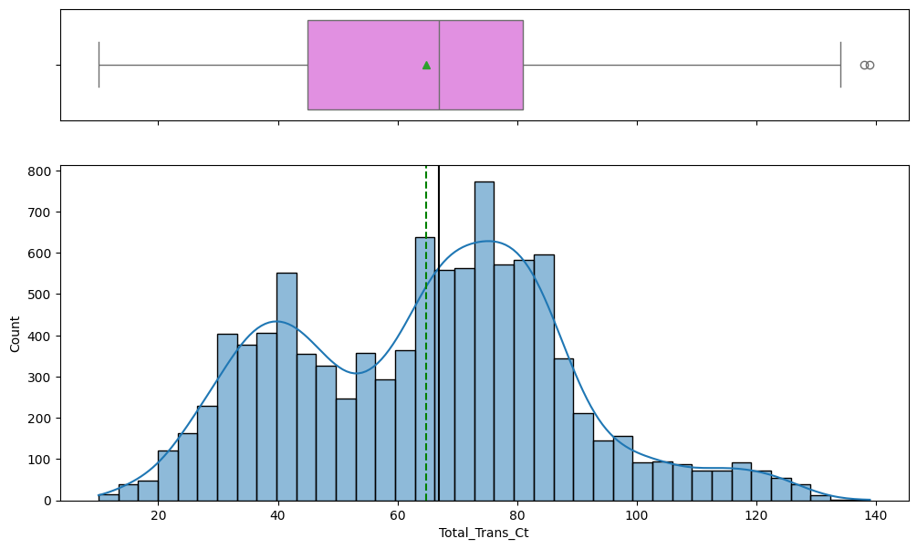

```python
# Generating a histogram and boxplot to observe distribution
histogram_boxplot(data, "Total_Trans_Ct", kde=True)
```

- The distribution displays a slight skeweness towards the right with a few outliers observed in the upper quartile.
- We observe a mean set a rough 65 transaction counts in a period of 12 months.

#### Average Utilization Ratio

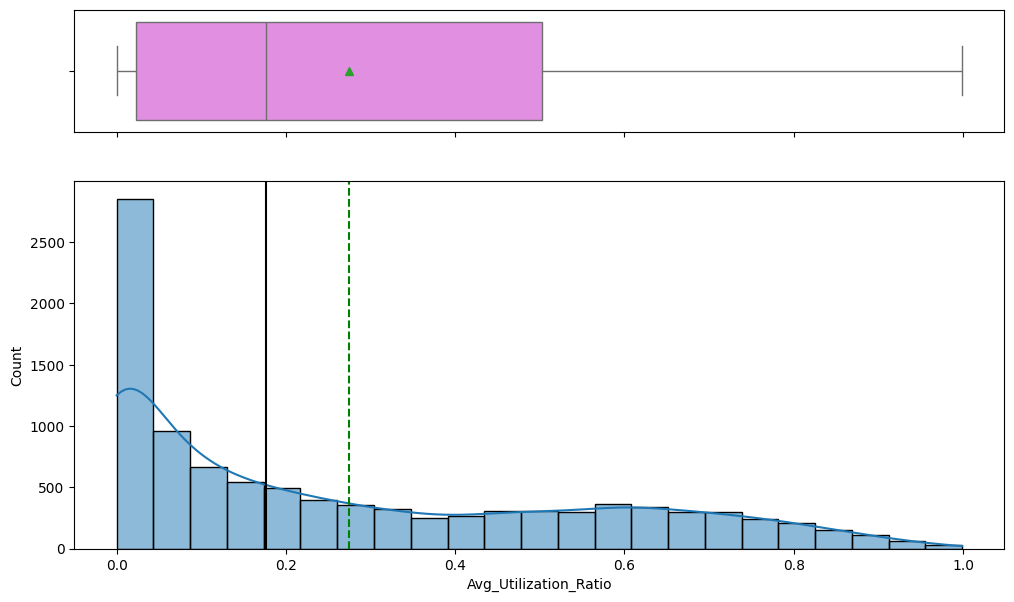

```python
# Generating a histogram and boxplot to observe distribution
histogram_boxplot(data, "Avg_Utilization_Ratio", kde=True)
```

### Categorical Columns Overview

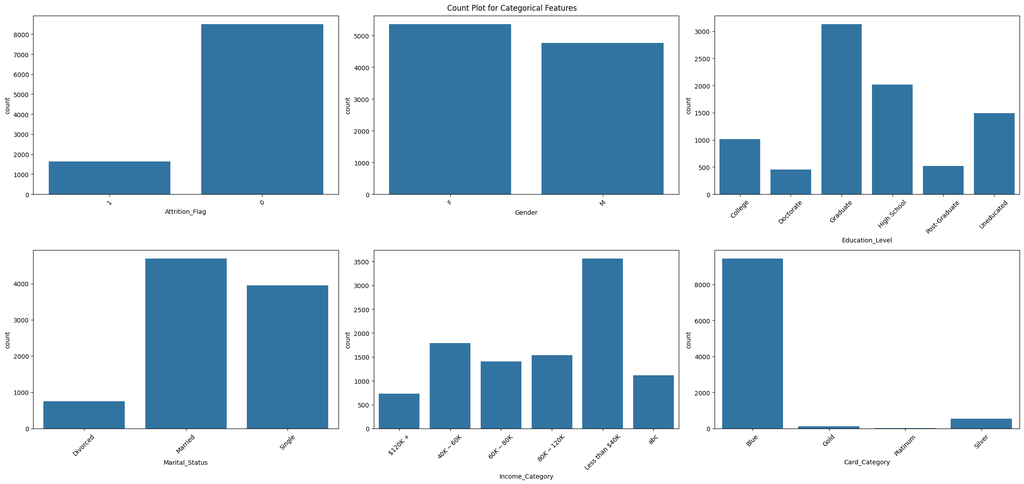

```python
# Defininh cat_col with the list of categorical column names
cat_col = data.select_dtypes(include=['category']).columns.tolist()

# creating count plots for categorical variables
fig, axes = plt.subplots(2, 3, figsize=(23, 11))
fig.suptitle("Count Plot for Categorical Features")

# Iterating over each categorical variable and corresponding subplot
for i, ax in enumerate(axes.flatten()):
    if i < len(cat_col):
        sns.countplot(x=cat_col[i], data=data, ax=ax)
        ax.set_xticklabels(ax.get_xticklabels(), rotation=45)

plt.tight_layout()
plt.show()
```

#### Attrition

```
Attrition_Flag
1    1627
0    8500
Name: CLIENTNUM, dtype: int64
```

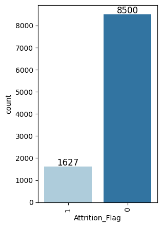

```python
# customer count for each group
attrition_count = data.groupby('Attrition_Flag')['CLIENTNUM'].count()
print(attrition_count)
print()

# Generating a barplot to observe distribution
labeled_barplot(data, "Attrition_Flag")
```

- A significant percentage of bank customers have been flagged as "attrited" making up a total of 16%.

#### Gender

```
Gender
F    5358
M    4769
Name: CLIENTNUM, dtype: int64
```

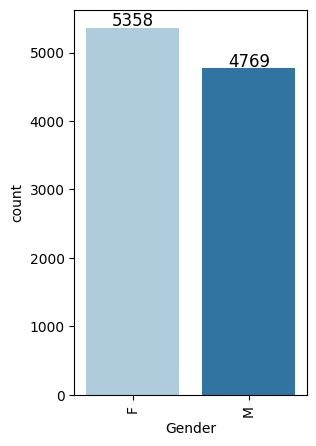

```python
# customer count for gender
gender_count = data.groupby('Gender')['CLIENTNUM'].count()
print(gender_count)
print()

# Generating a barplot to observe distribution
labeled_barplot(data, "Gender")
```

- The majority of bank customers have been labeled as 'female' (53%) with 47% being labelled as 'male'

#### Education

```
Education_Level
College          1013
Doctorate         451
Graduate         3128
High School      2013
Post-Graduate     516
Uneducated       1487
Name: CLIENTNUM, dtype: int64
```

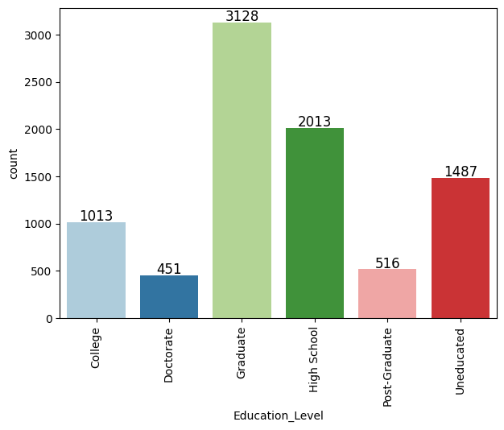

```python
# customer count for education level
education_count = data.groupby('Education_Level')['CLIENTNUM'].count()
print(education_count)
print()

# Generating a barplot to observe distribution
labeled_barplot(data, "Education_Level")
```

- The majority of customers seem to have obtained a 'graduate' degree level of education (31%) followed by 20% of customers who have obtained a 'high school' diploma, and 15% who were labelled as 'undeducated'.
- A minority of bank customers seem to either be college students (10%) or have obtained a post-graduate degree (5%) or a doctorate (4%).
- It's important to keep into consideration however that about 15% of the customer count has null values attributed.

#### Marital Status

```
Marital_Status
Divorced     748
Married     4687
Single      3943
Name: CLIENTNUM, dtype: int64
```

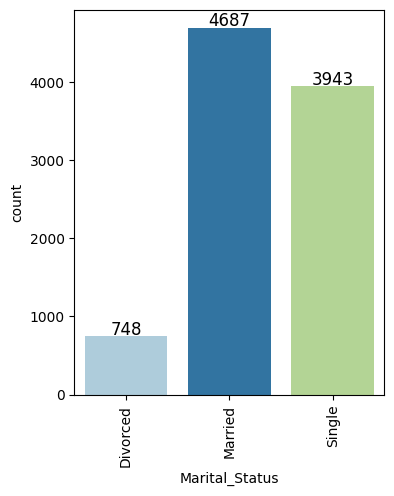

```python
# customer count for marital status
marital_count = data.groupby('Marital_Status')['CLIENTNUM'].count()
print(marital_count)
print()

# Generating a barplot to observe distribution
labeled_barplot(data, "Marital_Status")
```

- The majority of bank customers seem to be either 'Married' (46%) or 'Single' (39%) with only 7% of customers being labelled as 'Divorced'.
- It's however important to keep a note that about 7% of customers count has null values attributed.

#### Income Category

```
Income_Category
$120K +            727
$40K - $60K       1790
$60K - $80K       1402
$80K - $120K      1535
Less than $40K    3561
abc               1112
Name: CLIENTNUM, dtype: int64
```

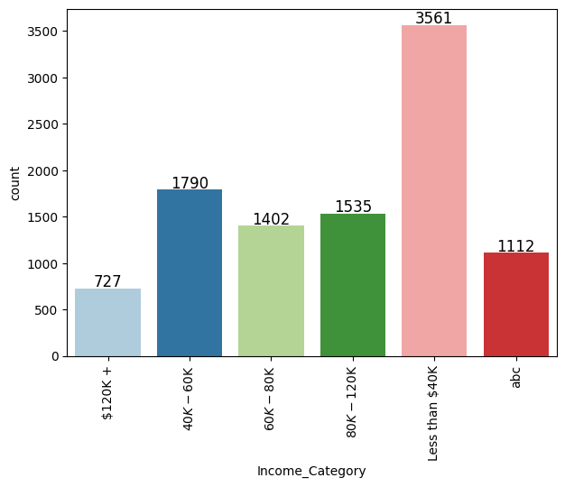

```python
# customer count for income category
income_category_count = data.groupby('Income_Category')['CLIENTNUM'].count()
print(income_category_count)
print()

# Generating a barplot to observe distribution
labeled_barplot(data, "Income_Category")
```

- We're observing that a majority of bank customers (35%) earn less than 40k, followed by those who earn 40-60k (18%), 80-120k (15%), 60-80k (14%), and 7% earning above 120k.
- It's worth nothing that those marked as 'abc' will be considered null at data preprocessing.

#### Card Category

```
Card_Category
Blue        9436
Gold         116
Platinum      20
Silver       555
Name: CLIENTNUM, dtype: int64
```

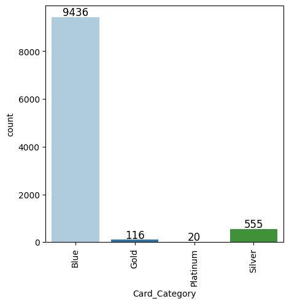

```python
# customer count for card category
card_category_count = data.groupby('Card_Category')['CLIENTNUM'].count()
print(card_category_count)
print()

# Generating a barplot to observe distribution
labeled_barplot(data, "Card_Category")
```

- We're obseving that a vast majority of customers seem to have adopted card 'Blue' (93%) wit very small minorities represented in other cards - silver (5%), gold (1.14%) and platinum (0.19%).

## Bivariate Analysis

#### Attrition & Gender

```
Attrition_Flag     1     0    All
Gender
All             1627  8500  10127
F                930  4428   5358
M                697  4072   4769
------------------------------------------------------------------------------------------------------------------------
```

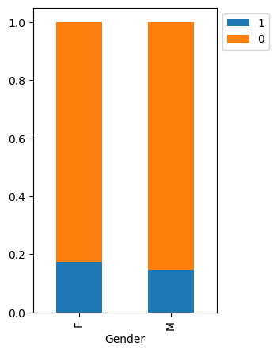

```python
# Creating a stacked barplot
stacked_barplot(data, "Gender", "Attrition_Flag")
```

- Among Female customers, 930 out of 5358 (17%) have attrited
- Among Male customers, 697 out of 4769 (15%) have attrited

Denoting a slight higher attrition rate amongst female customers.

#### Attrition & Marital Status

```
Attrition_Flag     1     0   All
Marital_Status
All             1498  7880  9378
Married          709  3978  4687
Single           668  3275  3943
Divorced         121   627   748
------------------------------------------------------------------------------------------------------------------------
```

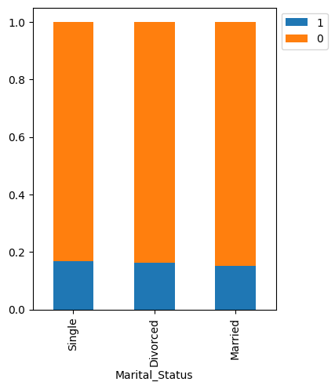

```python
# Creating a stacked barplot
stacked_barplot(data, "Marital_Status", "Attrition_Flag")
```

- Among Married customers, 709 out of 4687 (15%) have attrited
- Among Single customers, 668 out of 3943 (17%) have attrited
- Among Divorced customers, 121 out of 748 (16%) have attrited
- Among customers with Unknown marital status, 129 out of 749 (17%) have attrited

Denoting a slightly lower attrition rate amongst married customers.

#### Attrition & Education

```
Attrition_Flag      1     0   All
Education_Level
All              1371  7237  8608
Graduate          487  2641  3128
High School       306  1707  2013
Uneducated        237  1250  1487
College           154   859  1013
Doctorate          95   356   451
Post-Graduate      92   424   516
------------------------------------------------------------------------------------------------------------------------
```

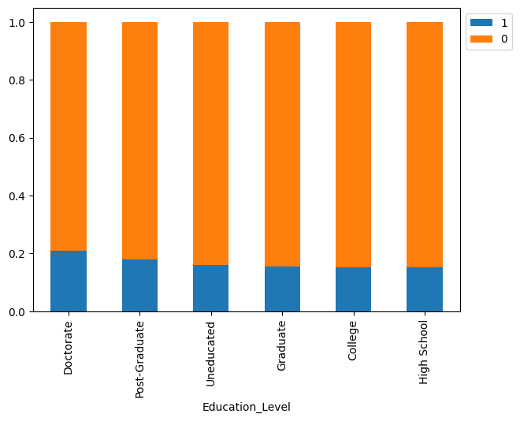

```python
# Creating a stacked barplot
stacked_barplot(data, "Education_Level", "Attrition_Flag")
```

- Among Graduate customers, 487 out of 3128 (16%) have attrited.
- Among High School customers, 306 out of 2013 (15%) have attrited.
- Among Uneducated customers, 237 out of 1487 (16%) have attrited.
- Among College customers, 154 out of 1013 (15%) have attrited.
- Among Doctorate customers, 95 out of 451 (21%) have attrited.
- Among Post-Graduate customers, 92 out of 516 (18%) have attrited.
- Among customers with Unknown education level, 256 out of 1519 (17%) have attrited.

Denoting a slightly higher attrition rates amongst customer with a post-graduate or doctorate degree and a slightly lower attritition rate amongst customers with a high-school diplma or college students.

#### Attrition & Income

```
Attrition_Flag      1     0    All
Income_Category
All              1627  8500  10127
Less than $40K    612  2949   3561
$40K - $60K       271  1519   1790
$80K - $120K      242  1293   1535
$60K - $80K       189  1213   1402
Unknown           187   925   1112
$120K +           126   601    727
------------------------------------------------------------------------------------------------------------------------
```

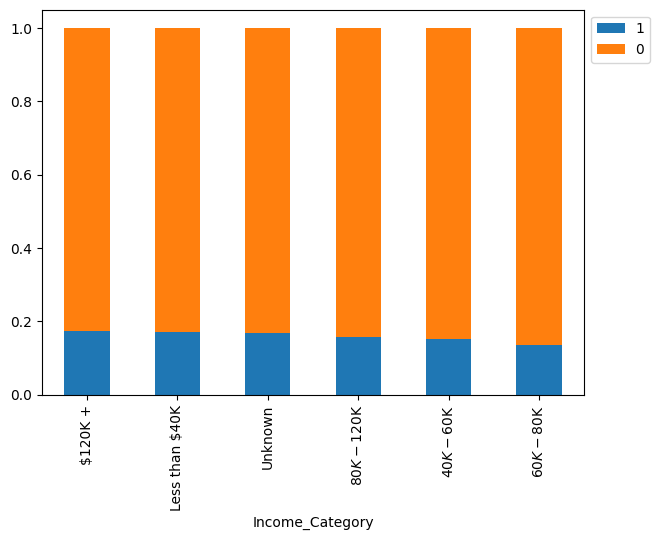

```python
# Replacing 'abc' with 'Unknown' in the 'Income_Category' column
data['Income_Category'].replace('abc', 'Unknown', inplace=True)

# Creating a stacked barplot
stacked_barplot(data, "Income_Category", "Attrition_Flag")
```

- Among customers with income less than 40K, 612 out of 3561 (17%) have attrited.
- Among customers with income between 40K and 60K, 271 out of 1790 (15%) have attrited.
- Among customers with income between 80K and 120K, 242 out of 1535 (16%) have attrited.
- Among customers with income between 60K and 80K, 189 out of 1402 (13%) have attrited.
- Among customers with income $120K and above, 126 out of 727 (17%) have attrited.
- Among customers with unknown income category, 187 out of 1112 (17%) have attrited.

Denoting a slightly lower rate of attrition amongst customers who earn between 60k and 80k and a slightly higher rate of attrition amongst customers who earn less than 40k and more than 120k

#### Attrition & Contact Counts

```
Attrition_Flag            1     0    All
Contacts_Count_12_mon
All                    1627  8500  10127
3                       681  2699   3380
2                       403  2824   3227
4                       315  1077   1392
1                       108  1391   1499
5                        59   117    176
6                        54     0     54
0                         7   392    399
------------------------------------------------------------------------------------------------------------------------
```

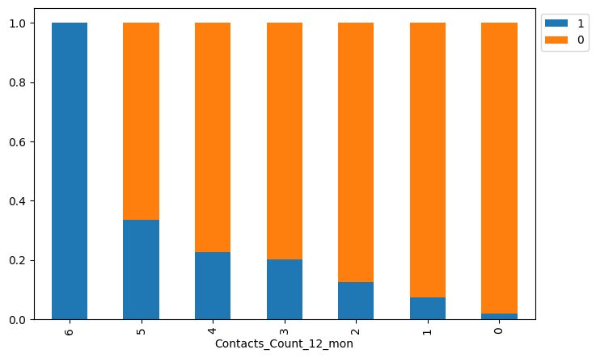

```python
# Creating a stacked barplot
stacked_barplot(data, "Contacts_Count_12_mon", "Attrition_Flag")
```

- Among customers with 0 contacts in the last 12 months, 7 out of 399 (2%) have attrited.
- Among customers with 1 contact in the last 12 months, 108 out of 1499 (7%) have attrited.
- Among customers with 2 contacts in the last 12 months, 403 out of 3227 (12%) have attrited.
- Among customers with 3 contacts in the last 12 months, 681 out of 3380 (20%) have attrited.
- Among customers with 4 contacts in the last 12 months, 315 out of 1392 (23%) have attrited.
- Among customers with 5 contacts in the last 12 months, 59 out of 176 (34%) have attrited.
- Among customers with 6 contacts in the last 12 months, 54 out of 54 (100%) have attrited.

Based on the above analysis, there's a very clear indication that attrition rates could have a significant correlation to contact count - where attrition rates appear to increase the more times a customer contacts the bank.

#### Attrition & Inactive Months

```
Attrition_Flag             1     0    All
Months_Inactive_12_mon
All                     1627  8500  10127
3                        826  3020   3846
2                        505  2777   3282
4                        130   305    435
1                        100  2133   2233
5                         32   146    178
6                         19   105    124
0                         15    14     29
------------------------------------------------------------------------------------------------------------------------
```

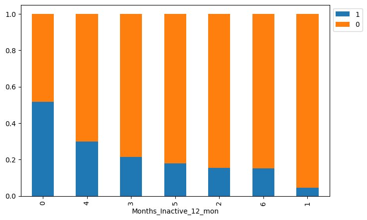

```python
# Creating a stacked barplot
stacked_barplot(data, "Months_Inactive_12_mon", "Attrition_Flag")
```

- Among customers with 0 months of inactivity in the last 12 months, 15 out of 29 (52%) have attrited.
- Among customers with 1 month of inactivity in the last 12 months, 100 out of 2233 (4%) have attrited.
- Among customers with 2 months of inactivity in the last 12 months, 505 out of 3282 (15%) have attrited.
- Among customers with 3 months of inactivity in the last 12 months, 826 out of 3846 (21%) have attrited.
- Among customers with 4 months of inactivity in the last 12 months, 130 out of 435 (30%) have attrited.
- Among customers with 5 months of inactivity in the last 12 months, 32 out of 178 (18%) have attrited.
- Among customers with 6 months of inactivity in the last 12 months, 19 out of 124 (15%) have attrited.

The above analysis seems to denote a significant pattern of higher attrition rates associated with those who had 0 months of inactivity, followed by those with 4 months of inactivity, while 1 month of inactivity appear to be associated with lower rates of attrition.

#### Attrition & Relationship Count (Product Count)

```
Attrition_Flag               1     0    All
Total_Relationship_Count
All                       1627  8500  10127
3                          400  1905   2305
2                          346   897   1243
1                          233   677    910
5                          227  1664   1891
4                          225  1687   1912
6                          196  1670   1866
------------------------------------------------------------------------------------------------------------------------
```

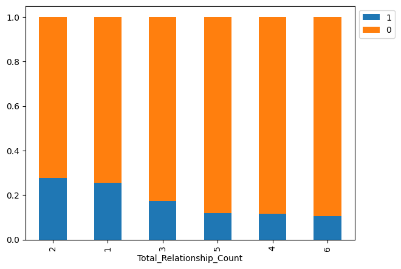

```python
# Creating a stacked barplot
stacked_barplot(data, "Total_Relationship_Count", "Attrition_Flag")
```

- Among customers with 1 total relationship count, 233 out of 910 (26%) have attrited.
- Among customers with 2 total relationship count, 346 out of 1243 (28%) have attrited.
- Among customers with 3 total relationship count, 400 out of 2305 (17%) have attrited.
- Among customers with 4 total relationship count, 225 out of 1912 (12%) have attrited.
- Among customers with 5 total relationship count, 227 out of 1891 (12%) have attrited.
- Among customers with 6 total relationship count, 196 out of 1866 (11%) have attrited.

The above analysis seems to denote a pattern of higher attrition rates associated with customers who only have 1 or 2 products, with the lowest attrition rates observed amongst customers with 4 or more products.

#### Attrition & Dependent

```
Attrition_Flag      1     0    All
Dependent_count
All              1627  8500  10127
3                 482  2250   2732
2                 417  2238   2655
1                 269  1569   1838
4                 260  1314   1574
0                 135   769    904
5                  64   360    424
------------------------------------------------------------------------------------------------------------------------
```

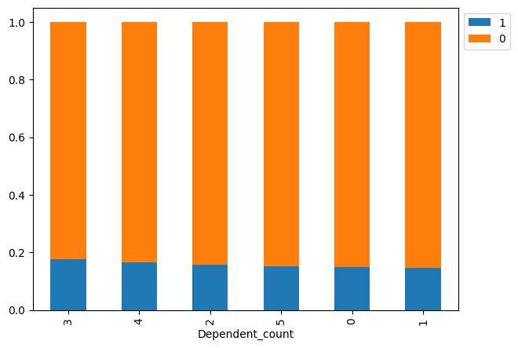

```python
# Creating a stacked barplot
stacked_barplot(data, "Dependent_count", "Attrition_Flag")
```

- Among customers with 0 dependents, 135 out of 904 (15%) have attrited.
- Among customers with 1 dependent, 269 out of 1838 (15%) have attrited.
- Among customers with 2 dependents, 417 out of 2655 (16%) have attrited.
- Among customers with 3 dependents, 482 out of 2732 (18%) have attrited.
- Among customers with 4 dependents, 260 out of 1574 (17%) have attrited.
- Among customers with 5 dependents, 64 out of 424 (15%) have attrited.

The above analysis seems to denote a very slight pattern of higher attrition rates observed amongst customers who have 3 and 4 dependents. The difference is however minor.

#### Attrition & Card Type

```
Attrition_Flag     1     0    All
Card_Category
All             1627  8500  10127
Blue            1519  7917   9436
Silver            82   473    555
Gold              21    95    116
Platinum           5    15     20
------------------------------------------------------------------------------------------------------------------------
```

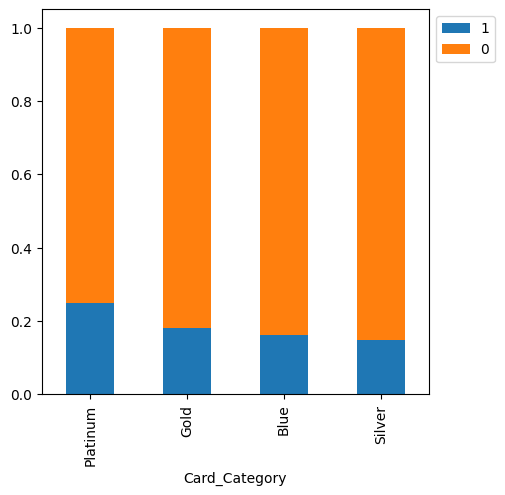

```python
# Creating a stacked barplot
stacked_barplot(data, "Card_Category", "Attrition_Flag")
```

- Among customers with Blue card category, 1519 out of 9436 (16%) have attrited.
- Among customers with Silver card category, 82 out of 555 (15%) have attrited.
- Among customers with Gold card category, 21 out of 116 (18%) have attrited.
- Among customers with Platinum card category, 5 out of 20 (25%) have attrited.

The above analysis seems to denote a slightly higher attrition rate amongst those who have a platinum and gold cards.